# Visualize EBV Detection

Veronica Russell, Dr. Dave Lab Rotation

5/6/2020

# Description:

## INPUT:

#### required column headers:

sample_id - davelab Sample Id of form #_T_1

analysis_id - davelab Analysis ID number

panel - categorical “1MB”, “8MB”, “110MB”, or “other”

ebv_positive - categorical “yes”, “weak”, “no”, “unknown” known EBV positive sample, determined from WHO pathology reports at https://who.davelab.org

sample_type - categorical “FFPE”,“cell line”, “other”

mean_coverage - RNA sample mean coverage determined from qc report at db.davelab.org under depth_of_coverage_aligned_read_stats

ebv_count - ebv reads (single) count determined from sum of quantified reads of ebv_detection module output ebv_detection_EBV_detection.{SAMPLE_ID}_A{ANALYSIS_ID}_ebv_paired_Aligned.out.sam and ebv_detection_EBV_detection.{SAMPLE_ID}_A{ANALYSIS_ID}_ebv_singles_Aligned.out.sam

unique_ebv_count - unique read (single) counts determined from sum of unique reads extracted from ebv_detection module output ebv_detection_EBV_detection.{SAMPLE_ID}_A{ANALYSIS_ID}ebv_paired_Log.final.out and ebv_detection_EBV_detection.{SAMPLE_ID}_A{ANALYSIS_ID}ebv_singles_Log.final.out

#### optional headers

*can be used as alternates for mean_coverage at all locations in this script (may require information outside of pathology report, qc report, or ebv_detection analysis):

total_sample_readprs - from qc report at db.davelab.org under Total TNA stats Total Input Read Pairs

total_rna_readprs - from qc report at db.davelab.org under Total TNA stats Total RNA Read Pairs

total_human_unmapped_reads - processed reads reported by samtools view -f4 -F1024 {IN_BAM} -c divided by 2 (for pairs)

mapped_pls_unmapped_reads - processed reads reported by samtools view -F3328 {IN_BAM} -c divided by 2 (for pairs)

## OUTPUT

1. Visualization summary plot of full .csv file and all panels
2. Visualization of individual panels

# Setup:

## Load Libaries

```r
library(ggplot2)
library(tidyverse)
```

## Set themes (provided by Dr. Sara Selitsky)

```r
theme_sara_90 <- function() {
  theme_bw(base_size=14)+
    theme(axis.text.x=element_text(angle=90,hjust = 1,vjust = 0.5),
          axis.text=element_text(color="black"),
          panel.background=element_rect(color="black"),
          strip.text = element_text(size=12),
          strip.background = element_rect(fill="white"))
}
```

## Import data

```r
star_ebv_data <- read.csv(file='star_counts_ebvmasked_f4F1024.csv')
head(star_ebv_data)
```

|  | analysis_id | sample_id | panel | ebv_positive | FFPE | total_unmapped_reads | ebv_count | mean_coverage | total_rna_reads | total_reads | mapped_pls_unmapped_reads |
| --- | --- | --- | --- | --- | --- | --- | --- | --- | --- | --- | --- |
| 1 | 8184 | 12283_T_1 | 1MB | no | yes | 71653 | 6 | 82.63 | 13948404 | 23002650 | 5550757 |
| 2 | 8186 | 12287_T_1 | 1MB | no | yes | 61357 | 0 | 91.17 | 6630020 | 18538541 | 3255400 |
| 3 | 8191 | 12319_T_1 | 1MB | no | yes | 56361 | 137 | 40.78 | 28328522 | 20452207 | 8484708 |
| 4 | 8192 | 12322_T_1 | 1MB | yes | yes | 86672 | 97 | 108.20 | 7999894 | 25752120 | 3881515 |
| 5 | 8199 | 13276_T_1 | 1MB | yes | yes | 221693 | 89 | 406.21 | 30854130 | 51331959 | 11745446 |
| 6 | 8220 | 14296_T_1 | 1MB | no | yes | 102246 | 86 | 62.52 | 44723422 | 33161355 | 14965169 |

# Data Processing:

```r
#fix where zero with adding 1/2 smallest zero value to all zeroes then taking log
star_ebv_data$ebv_count[star_ebv_data$ebv_count==0]<- 1
star_ebv_data$log_ebv_count <- log(star_ebv_data$ebv_count)
head(star_ebv_data)
```

|  | analysis_id | sample_id | panel | ebv_positive | FFPE | total_unmapped_reads | ebv_count | mean_coverage | total_rna_reads | total_reads | mapped_pls_unmapped_reads | log_ebv_count |
| --- | --- | --- | --- | --- | --- | --- | --- | --- | --- | --- | --- | --- |
| 1 | 8184 | 12283_T_1 | 1MB | no | yes | 71653 | 6 | 82.63 | 13948404 | 23002650 | 5550757 | 1.791759 |
| 2 | 8186 | 12287_T_1 | 1MB | no | yes | 61357 | 1 | 91.17 | 6630020 | 18538541 | 3255400 | 0.000000 |
| 3 | 8191 | 12319_T_1 | 1MB | no | yes | 56361 | 137 | 40.78 | 28328522 | 20452207 | 8484708 | 4.919981 |
| 4 | 8192 | 12322_T_1 | 1MB | yes | yes | 86672 | 97 | 108.20 | 7999894 | 25752120 | 3881515 | 4.574711 |
| 5 | 8199 | 13276_T_1 | 1MB | yes | yes | 221693 | 89 | 406.21 | 30854130 | 51331959 | 11745446 | 4.488636 |
| 6 | 8220 | 14296_T_1 | 1MB | no | yes | 102246 | 86 | 62.52 | 44723422 | 33161355 | 14965169 | 4.454347 |

```r
#Split data for panel types included in dataframe
by_panel <- split(star_ebv_data, star_ebv_data$panel)

#select column variable indicative of graph point size (default=mean_coverage)
#if using optional column headers can replace "mean_coverage" with any desired measure of sample total reads or quality
size_var=star_ebv_data$mean_coverage
```

# Graphs:

## Metadata Sample Coverage Boxplots

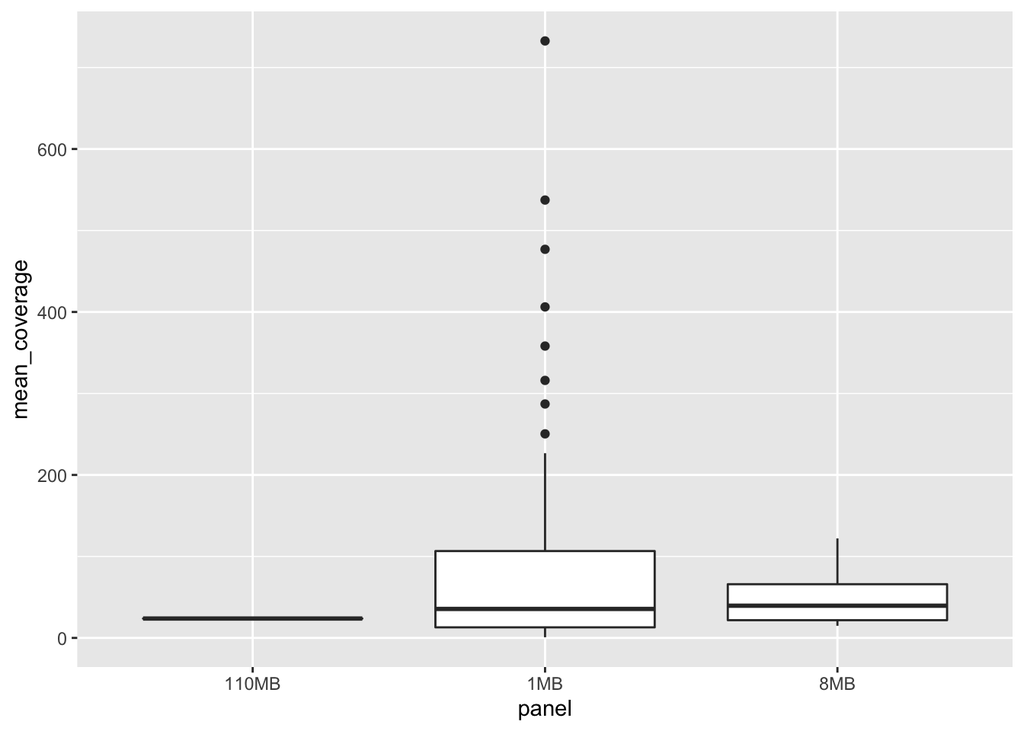

```r
ggplot(star_ebv_data, aes(x=panel, y=mean_coverage))+xlab("panel")+ylab("mean_coverage")+geom_boxplot()
```

## All Panel Summary Graph

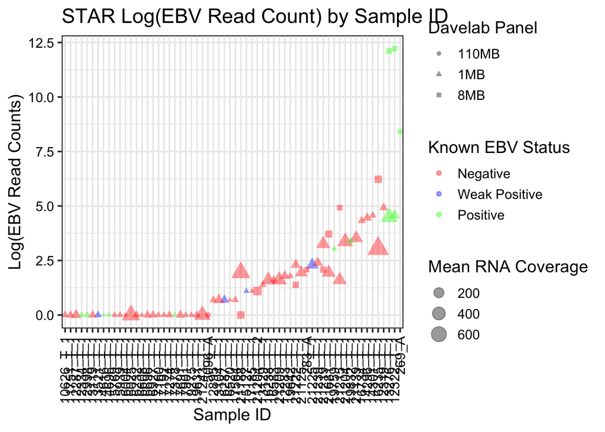

```r
#if using optional column headers can replace "mean_coverage" with any desired measure of sample total reads or quality
gg_star_all_samples <- ggplot(star_ebv_data, aes(x=reorder(sample_id, log_ebv_count), y=log_ebv_count, color=ebv_positive, size=size_var)) + geom_point(aes(shape=panel), alpha=0.4) +   scale_color_manual(name = "Known EBV Status",
                     values = c("yes" = "green",
                                "weak" = "blue",
                                "no" = "red",
                                "unknown" = "gray"),
                     labels = c("yes" = "Positive",
                                "weak" = "Weak Positive",
                                "no" = "Negative",
                                "unknown" = "Unknown")) +
scale_shape_manual(name = "Davelab Panel",
                   values=c("1MB" = 17,
                            "8MB" = 15,
                            "110MB" = 16,
                            "other" = 18)) +
scale_size_continuous(name="Mean RNA Coverage") +
theme_sara_90() + labs(title="STAR Log(EBV Read Count) by Sample ID", x="Sample ID", y="Log(EBV Read Counts)")

gg_star_all_samples
```

## Individual Panels Graphs

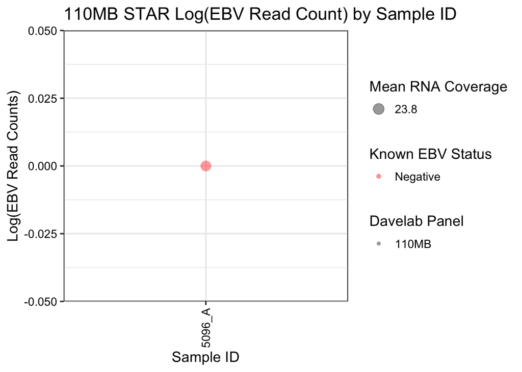

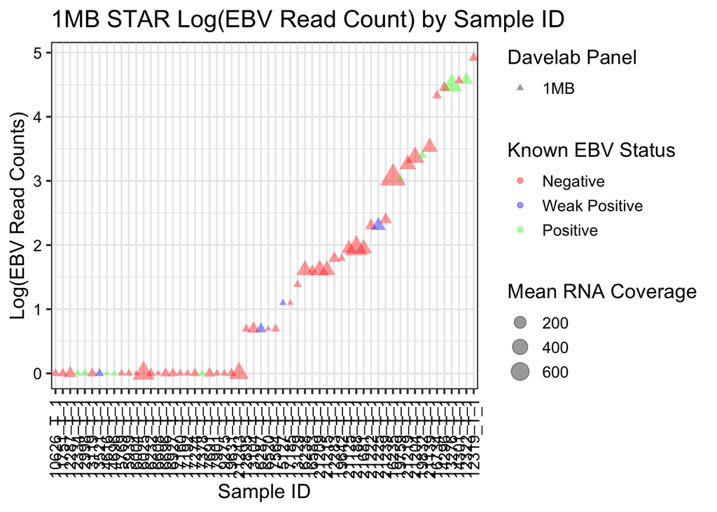

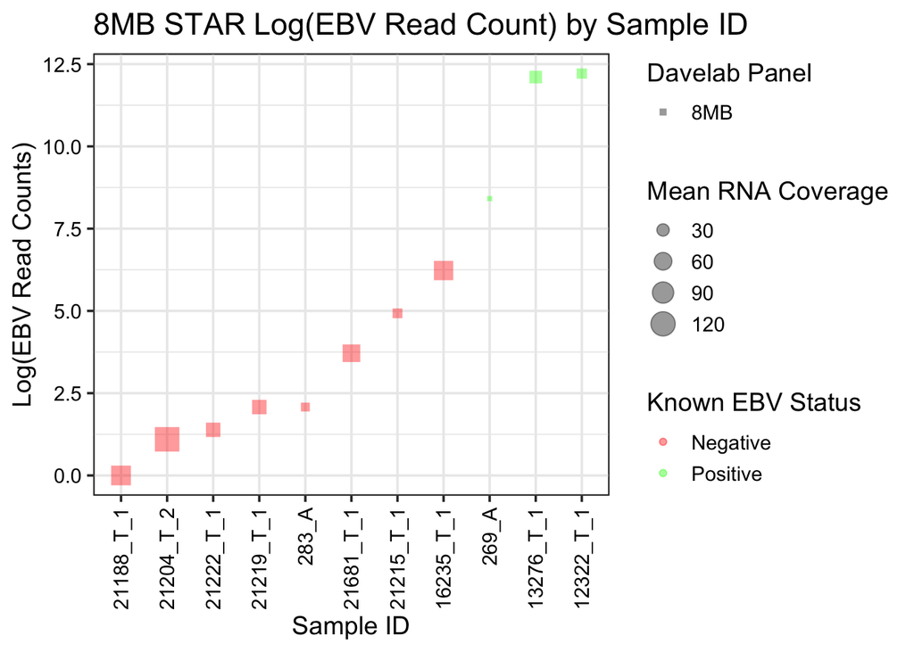

```r
for (x in names(by_panel)) {
  panel <- subset(star_ebv_data, panel==x)
  #if using optional column headers can replace "mean_coverage" with any desired measure of sample total reads or quality
  size_var2 <- panel$mean_coverage
  plot_title=paste("gg_star_",x,"_panel",sep="")
  plot_title <- ggplot(panel, aes(x=reorder(sample_id, log_ebv_count), y=log_ebv_count, color=ebv_positive, size=size_var2)) + geom_point(aes(shape=panel), alpha=0.4) +
     scale_color_manual(name = "Known EBV Status",
                     values = c("yes" = "green",
                                "weak" = "blue",
                                "no" = "red",
                                "unknown" = "gray"),
                     labels = c("yes" = "Positive",
                                "weak" = "Weak Positive",
                                "no" = "Negative",
                                "unknown" = "Unknown")) +
      scale_shape_manual(name = "Davelab Panel",
                     values=c("1MB" = 17,
                              "8MB" = 15,
                              "110MB" = 16,
                              "other" = 18)) +
     scale_size_continuous(name="Mean RNA Coverage") +
     theme_sara_90() + labs(title=paste(x,"STAR Log(EBV Read Count) by Sample ID",sep=" "), x="Sample ID", y="Log(EBV Read Counts)")

  print(plot_title)
}
```